# Реструктуризация данных в R с помощью tidyr

9 октября 2017 г

```r
library(tidyverse)
# Раскомментируйте и запустите следующие команды,
# если у вас не ставится tidyverse
#library(dplyr)
#library(tidyr)
#library(ggplot2)
```

# Хорошо упорядоченные данные (tidy data)

Данные могут быть представлены в различной форме. Следующие таблицы содержат одни и те же данные - динамику количества случаев заболевания (`cases`) и численности населения (`population`) в разных странах (`country`). Хотя данные одни и те же, структура таблиц различается:

```r
table1
```

```
## # A tibble: 6 x 4
##       country  year  cases population
##         <chr> <int>  <int>      <int>
## 1 Afghanistan  1999    745   19987071
## 2 Afghanistan  2000   2666   20595360
## 3      Brazil  1999  37737  172006362
## 4      Brazil  2000  80488  174504898
## 5       China  1999 212258 1272915272
## 6       China  2000 213766 1280428583
```

```r
table2
```

```
## # A tibble: 12 x 4
##        country  year       type      count
##          <chr> <int>      <chr>      <int>
##  1 Afghanistan  1999      cases        745
##  2 Afghanistan  1999 population   19987071
##  3 Afghanistan  2000      cases       2666
##  4 Afghanistan  2000 population   20595360
##  5      Brazil  1999      cases      37737
##  6      Brazil  1999 population  172006362
##  7      Brazil  2000      cases      80488
##  8      Brazil  2000 population  174504898
##  9       China  1999      cases     212258
## 10       China  1999 population 1272915272
## 11       China  2000      cases     213766
## 12       China  2000 population 1280428583
```

```r
table3
```

```
## # A tibble: 6 x 3
##       country  year              rate
## *       <chr> <int>             <chr>
## 1 Afghanistan  1999      745/19987071
## 2 Afghanistan  2000     2666/20595360
## 3      Brazil  1999   37737/172006362
## 4      Brazil  2000   80488/174504898
## 5       China  1999 212258/1272915272
## 6       China  2000 213766/1280428583
```

```r
table4a # cases
```

```
## # A tibble: 3 x 3
##       country `1999` `2000`
## *       <chr>  <int>  <int>
## 1 Afghanistan    745   2666
## 2      Brazil  37737  80488
## 3       China 212258 213766
```

```r
table4b # population
```

```
## # A tibble: 3 x 3
##       country     `1999`     `2000`
## *       <chr>      <int>      <int>
## 1 Afghanistan   19987071   20595360
## 2      Brazil  172006362  174504898
## 3       China 1272915272 1280428583
```

```r
table5
```

```
## # A tibble: 6 x 4
##       country century  year              rate
## *       <chr>   <chr> <chr>             <chr>
## 1 Afghanistan      19    99      745/19987071
## 2 Afghanistan      20    00     2666/20595360
## 3      Brazil      19    99   37737/172006362
## 4      Brazil      20    00   80488/174504898
## 5       China      19    99 212258/1272915272
## 6       China      20    00 213766/1280428583
```

**Вопрос:** В каком из представлений легче всего рассчитать в R относительную частоту заболевания - число случаев на 10000 жителей?

Наиболее удобно представление данных, в котором:

- все переменные расположены по столбцам,
- все наблюдения - по строкам,
- в каждой ячейке таблицы хранится одно значение.

Данные в такой форме будем называть **хорошо упорядоченными** (tidy).

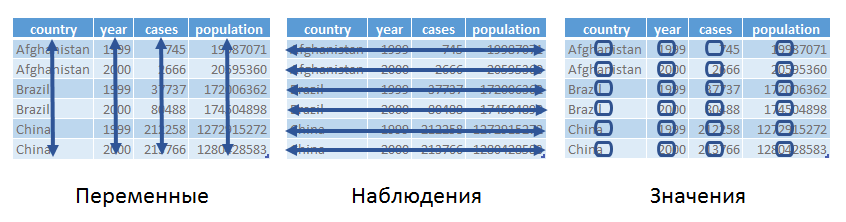

“Хорошо упорядоченные” данные

Преимуществом такой формы представления данных является единообразие: любая операция выполняется со столбцами таблицы, не требуется дополнительных действий, чтобы обратиться к нужным данным. Большинство функций в R ориентированы на векторную обработку значений, то есть они работают именно со столбцами значений.

**Вопрос:** где находятся переменные в рассмотренных примерах таблиц?

# Плохо упорядоченные данные (messy data)

В противоположность “хорошо упорядоченным” данным, все остальные представления данных можно назвать **“плохо упорядоченными”** (messy). Этот термин означает лишь то, что обработка таких данных функциями для работы с таблицами будет более трудной. Это не значит, что сами данные - плохие или непригодные к анализу. Бывают ситуации, когда “плохая” для компьютерной обработки структура данных оказывается более удобной для человека - например, нам удобнее следить за динамикой показателей в сводных таблицах, где разные периоды времени отражаются отдельными столбцами.

Иногда данные приходится специально делать “плохо упорядоченными”, объединяя несколько переменных в одном столбце, чтобы обеспечить их автоматизированную обработку.

Например, если требуется визуализировать динамику населения и количества случаев заболеваний, то для “плохо упорядоченного” набора данных это можно сделать одной командой, а для “хорошо упорядоченного” потребуется несколько.

```r
table2
```

```
## # A tibble: 12 x 4
##        country  year       type      count
##          <chr> <int>      <chr>      <int>
##  1 Afghanistan  1999      cases        745
##  2 Afghanistan  1999 population   19987071
##  3 Afghanistan  2000      cases       2666
##  4 Afghanistan  2000 population   20595360
##  5      Brazil  1999      cases      37737
##  6      Brazil  1999 population  172006362
##  7      Brazil  2000      cases      80488
##  8      Brazil  2000 population  174504898
##  9       China  1999      cases     212258
## 10       China  1999 population 1272915272
## 11       China  2000      cases     213766
## 12       China  2000 population 1280428583
```

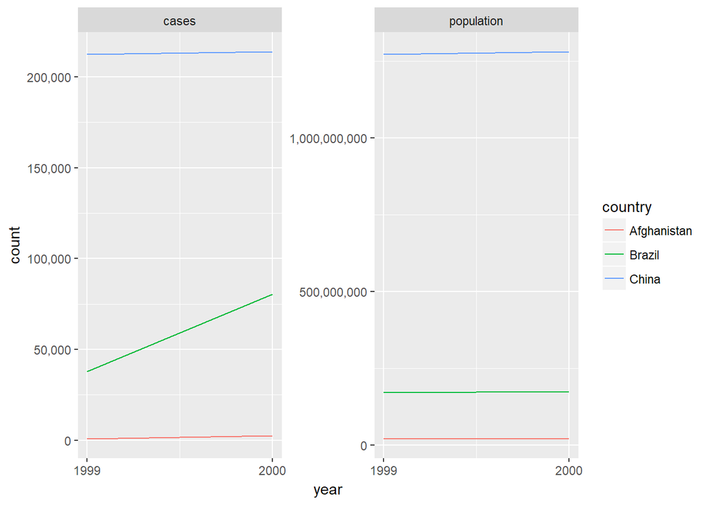

```r
ggplot(data = table2) +
  geom_line(mapping = aes(color = country,
                          x = year,
                          y = count)) +
  facet_wrap(~ type, scales = 'free_y') +
  scale_y_continuous(labels = scales::comma) +
  scale_x_continuous(breaks = 1999:2000)
```

```r
table1
```

```
## # A tibble: 6 x 4
##       country  year  cases population
##         <chr> <int>  <int>      <int>
## 1 Afghanistan  1999    745   19987071
## 2 Afghanistan  2000   2666   20595360
## 3      Brazil  1999  37737  172006362
## 4      Brazil  2000  80488  174504898
## 5       China  1999 212258 1272915272
## 6       China  2000 213766 1280428583
```

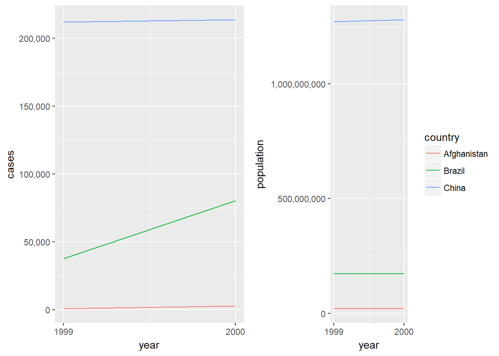

```r
# Динамика случаев заболевания
p1 <- ggplot(data = table1) +
  geom_line(mapping = aes(color = country,
                          x = year,
                          y = cases)) +
  scale_y_continuous(labels = scales::comma) +
  scale_x_continuous(breaks = 1999:2000) +
  scale_color_discrete(guide = FALSE)

# Динамика населения
p2 <- ggplot(data = table1) +
  geom_line(mapping = aes(color = country,
                          x = year,
                          y = population)) +
  scale_y_continuous(labels = scales::comma) +
  scale_x_continuous(breaks = 1999:2000)

# Собираем два графика на одну визуализацию
gridExtra::grid.arrange(p1, p2, ncol = 2)
```

# Как сделать данные “хорошо упорядоченными”?

В этом блокноте мы рассмотрим функции пакета `tidyr`, позволяющие привести данные к “хорошо упорядоченному” формату:

- `gather()` - свертка столбцов в строки;
- `spread()` - развертка строк в столбцы;
- `separate()` - разделение значений одного столбца на несколько;
- `unite()` - объединение значений нескольких столбцов в один.

Более подробно познакомиться с проблемой реструктурирования данных в следующих источниках:

- глава [Tidy Data книги R for Data Science](http://r4ds.had.co.nz/tidy-data.html)
- встроенные примеры пакета `tidyr` (выполните команду: `vignette('tidy-data')`).

## Свертка столбцов в строки с помощью функции `gather()`

Одной из проблем набора данных может быть то, что в названиях столбцов содержатся не названия переменных, а **значения** переменных. Чтобы привести данные к удобному формату, нужно **собрать** (gather) данные столбцов в две новые переменные.

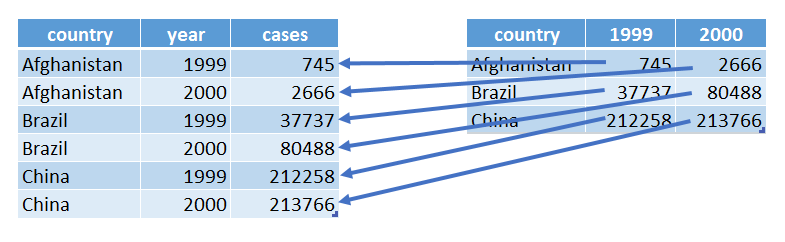

Работа функции `gather()`

Функция `gather()` имеет следующие параметры:

- `data` - набор данных;
- перечень столбцов, которые представляют собой значения переменных, а не их названия;
- `key` - название новой переменной, в которой будут храниться названия старых столбцов;
- `value` - название новой переменной, в которой будут храниться значения ячеек старых столбцов.

### Пример `gather()`

В наборе данных `table4a` названия столбцов `1999` и `2000` являются значениями переменной `year`. С помощью функции `gather()` данные столбцов будут свернуты в две переменные: `year` с названиями столбцов `1999` и `2000` и `cases` с значениями ячеек столбцов `1999` и `2000`.

```r
table4a
```

```
## # A tibble: 3 x 3
##       country `1999` `2000`
## *       <chr>  <int>  <int>
## 1 Afghanistan    745   2666
## 2      Brazil  37737  80488
## 3       China 212258 213766
```

```r
gather(table4a, `1999`,`2000`, key = "year", value = "cases")
```

```
## # A tibble: 6 x 3
##       country  year  cases
##         <chr> <chr>  <int>
## 1 Afghanistan  1999    745
## 2      Brazil  1999  37737
## 3       China  1999 212258
## 4 Afghanistan  2000   2666
## 5      Brazil  2000  80488
## 6       China  2000 213766
```

### Упражнения `gather()`

Произведите свертку столбцов следующего набора данных:

```r
sales <- tibble(
  goods = c("Milk", "Cheese", "Butter", "Sour cream"),
  moscow = c(350,430,360,570),
  `st-petersburg` = c(210,270,150,250),
  novosibirsk = c(120,150,210,140),
  total = c(680,850,720,960)
)
sales
```

```
## # A tibble: 4 x 5
##        goods moscow `st-petersburg` novosibirsk total
##        <chr>  <dbl>           <dbl>       <dbl> <dbl>
## 1       Milk    350             210         120   680
## 2     Cheese    430             270         150   850
## 3     Butter    360             150         210   720
## 4 Sour cream    570             250         140   960
```

```r
# Напишите свой код здесь
```

## Развертка строк в столбцы с помощью функции `spread()`

Иногда наблюдения “разбросаны” по нескольким строкам. В этом случае функция `spread()` позволяет собрать данные, относящиеся к одному наблюдению в одну строку.

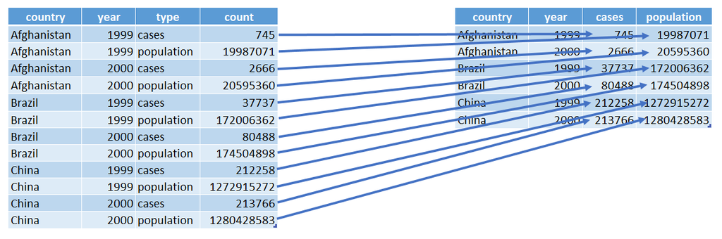

Работа функции `spread()`

Функция `spread()` имеет следующие параметры:

- `data` - набор данных;
- `key` - название столбца, в котором содержатся названия переменных, для которых будут созданы столбцы;
- `value` - название столбца, в котором содержатся значения переменных.

### Пример `spread()`

В наборе данных `table2` столбце `type` содержатся названия переменных `cases` и `population`, а в столбце `count` - значения переменных. С помощью функции `spread()` создадим переменные `cases` и `population` и перенесем в них значения из столбца `count`:

```r
table2
```

```
## # A tibble: 12 x 4
##        country  year       type      count
##          <chr> <int>      <chr>      <int>
##  1 Afghanistan  1999      cases        745
##  2 Afghanistan  1999 population   19987071
##  3 Afghanistan  2000      cases       2666
##  4 Afghanistan  2000 population   20595360
##  5      Brazil  1999      cases      37737
##  6      Brazil  1999 population  172006362
##  7      Brazil  2000      cases      80488
##  8      Brazil  2000 population  174504898
##  9       China  1999      cases     212258
## 10       China  1999 population 1272915272
## 11       China  2000      cases     213766
## 12       China  2000 population 1280428583
```

```r
spread(table2, key = type, value = count)
```

```
## # A tibble: 6 x 4
##       country  year  cases population
## *       <chr> <int>  <int>      <int>
## 1 Afghanistan  1999    745   19987071
## 2 Afghanistan  2000   2666   20595360
## 3      Brazil  1999  37737  172006362
## 4      Brazil  2000  80488  174504898
## 5       China  1999 212258 1272915272
## 6       China  2000 213766 1280428583
```

### Упражнения `spread()`

Произведите развертку строк следующего набора данных:

```r
grades <- tribble(
~name, ~subject, ~grade,
#-----------------|--------|------
"Ivan Ivanov", "Logistics", 4,
"Ivan Ivanov", "Research seminar", 5,
"Ivan Ivanov", "Logistics", 10,
"Peter Petrov", "Logistics", 8,
"Peter Petrov", "Research seminar", 8
)
grades
```

```
## # A tibble: 5 x 3
##           name          subject grade
##          <chr>            <chr> <dbl>
## 1  Ivan Ivanov        Logistics     4
## 2  Ivan Ivanov Research seminar     5
## 3  Ivan Ivanov        Logistics    10
## 4 Peter Petrov        Logistics     8
## 5 Peter Petrov Research seminar     8
```

```r
# Напишите свой код здесь
```

## Разделение значений столбца с помощью функции `separate()`

Иногда значения нескольких переменных могут быть записаны в одном столбце через разделитель. В этом случае для обработки значений этих переменных необходимо разнести их по столбцам. Справиться с этой проблемой позволяет функция `separate()`.

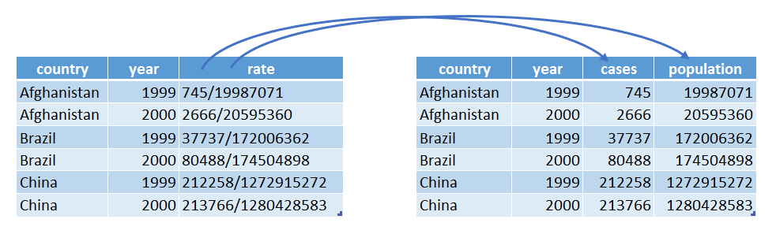

Работа функции `separate()`

Функция `separate()` имеет следующие параметры:

- `data` - набор данных;
- `col` - название столбца, содержащего значения, которые нужно разделить;
- `into` - вектор названий столбцов, в которые будут помещены разделенные значения;
- `sep` - разделитель значений, по умолчанию - любой встречающийся символ, не являющийся буквой или цифрой;
- `convert` - если параметр равен `TRUE`, то разделенные значения будут конвертированы в наиболее подходящие типы. Параметр особенно полезен, когда разделяемые значения - числовые.

### Пример `separate()`

В наборе данных `table3` в столбце `rate` записаны через разделитель “/” значения переменных `cases` и `population`. Разнесем их в соответствующие столбцы.

```r
table3
```

```
## # A tibble: 6 x 3
##       country  year              rate
## *       <chr> <int>             <chr>
## 1 Afghanistan  1999      745/19987071
## 2 Afghanistan  2000     2666/20595360
## 3      Brazil  1999   37737/172006362
## 4      Brazil  2000   80488/174504898
## 5       China  1999 212258/1272915272
## 6       China  2000 213766/1280428583
```

```r
separate(table3, rate, into = c("cases", "population"))
```

```
## # A tibble: 6 x 4
##       country  year  cases population
## *       <chr> <int>  <chr>      <chr>
## 1 Afghanistan  1999    745   19987071
## 2 Afghanistan  2000   2666   20595360
## 3      Brazil  1999  37737  172006362
## 4      Brazil  2000  80488  174504898
## 5       China  1999 212258 1272915272
## 6       China  2000 213766 1280428583
```

```r
separate(table3, rate, into = c("cases", "population"), convert = TRUE)
```

```
## # A tibble: 6 x 4
##       country  year  cases population
## *       <chr> <int>  <int>      <int>
## 1 Afghanistan  1999    745   19987071
## 2 Afghanistan  2000   2666   20595360
## 3      Brazil  1999  37737  172006362
## 4      Brazil  2000  80488  174504898
## 5       China  1999 212258 1272915272
## 6       China  2000 213766 1280428583
```

### Упражнения `separate()`

Разделите значения в следующего набора данных:

```r
addresses <- tibble(address = c(
  "123022, г. Москва, Б. Трехсвятительский пер., д.3",
  "105187, г. Москва, ул. Кирпичная, д.33",
  "100100, г. Москва, ул. Мясницкая, д.13, стр. 4"
)
)

# Напишите свой код здесь
```

## Объединение значений столбцов с помощью функции `unite()`

Функция `unite()` позволяет соединить значения нескольких столбцов в один.

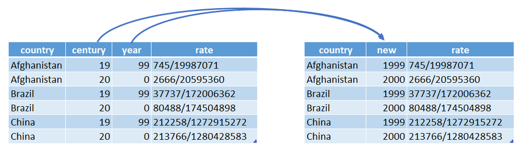

Работа функции unite()

Функция имеет следующие параметры:

- `data` - набор данных;
- `col` - название нового столбца, в котором будут соединенные значения;
- перечень столбцов, из которых будут соединяться значения;
- `sep` - разделитель значений в новом столбце, по умолчанию “_“.

### Пример `unite()`

В наборе данных `table5` первые и последние две цифры года разнесены по столбцам `century` и `year`. Соединим их в столбце `new`.

```r
table5
```

```
## # A tibble: 6 x 4
##       country century  year              rate
## *       <chr>   <chr> <chr>             <chr>
## 1 Afghanistan      19    99      745/19987071
## 2 Afghanistan      20    00     2666/20595360
## 3      Brazil      19    99   37737/172006362
## 4      Brazil      20    00   80488/174504898
## 5       China      19    99 212258/1272915272
## 6       China      20    00 213766/1280428583
```

```r
unite(table5, new, century, year, sep = "")
```

```
## # A tibble: 6 x 3
##       country   new              rate
## *       <chr> <chr>             <chr>
## 1 Afghanistan  1999      745/19987071
## 2 Afghanistan  2000     2666/20595360
## 3      Brazil  1999   37737/172006362
## 4      Brazil  2000   80488/174504898
## 5       China  1999 212258/1272915272
## 6       China  2000 213766/1280428583
```

### Упражнения `unite()`

Используя функцию unite(), создайте столбец, в котором для каждой даты проставлено соответствие времени года и год. Например, для даты “01-01-2017” - “зима 2017”.

```r
dates <- tibble(date = c("02-01-2015", "05-04-2015", "27-09-2017", "18-07-2016","09-12-2014"))

# Напишите свой код здесь
```